# A1 submission

22804897

2023

## Preliminary steps

### Data import, checking dimensions and data types, and setting the seed for sampling

```r
main_data <- read.csv('A1_data.csv', header=TRUE, stringsAsFactors = TRUE)
dim(main_data)
```

```
## [1] 2930   31
```

```r
str(main_data)
```

```
## 'data.frame':    2930 obs. of  31 variables:
##  $ Identifier       : int  26313445 26362385 26363355 26365375 27117355 27117375 27139495 27157425 27158375 27174475 ...
##  $ Price            : int  2150000 1050000 1720000 2440000 1899000 1955000 2135000 1915000 2365000 1890000 ...
##  $ Price_cat        : Factor w/ 3 levels "Average","High",..: 2 3 1 2 1 1 2 1 2 1 ...
##  $ Month_sold       : int  5 6 6 4 3 6 4 1 3 6 ...
##  $ Year_sold        : int  2020 2020 2020 2020 2020 2020 2020 2020 2020 2020 ...
##  $ Sale_type        : Factor w/ 2 levels "Normal","Other": 1 1 1 1 1 1 1 1 1 1 ...
##  $ Type             : Factor w/ 4 levels "Double storey",..: 4 4 4 4 1 1 3 3 3 1 ...
##  $ Area             : Factor w/ 4 levels "Agricultural",..: 4 4 4 4 4 4 4 4 4 4 ...
##  $ Size             : int  2952 1080 1325 1037 1285 927 457 465 501 697 ...
##  $ Street_front     : int  43 24 25 28 23 24 12 13 12 18 ...
##  $ Plot_shape       : Factor w/ 2 levels "Irregular","Regular": 1 2 1 2 1 1 2 1 1 2 ...
##  $ Incline          : Factor w/ 3 levels "Down","Flat",..: 2 2 2 2 2 2 2 3 2 2 ...
##  $ SlopeType        : Factor w/ 3 levels "Gentle","Moderate",..: 1 1 1 1 1 1 1 1 1 1 ...
##  $ Condition        : int  6 6 6 6 5 6 7 7 7 6 ...
```

[output cut: 17 more lines]

```r
set.seed(7)
```

### Sampling the data, sorting by Identifier and extracting the 1<sup>st</sup>, 10<sup>th</sup>, 20<sup>th</sup> and 100<sup>th</sup> Identifier values

```r
test_data <- sample_n(main_data, 2500, replace = FALSE)
test_data <- test_data[order(test_data$Identifier, decreasing = FALSE),]

test_data[1,]$Identifier
```

```
## [1] 26313445
```

```r
test_data[10,]$Identifier
```

```
## [1] 26365375
```

```r
test_data[20,]$Identifier
```

```
## [1] 27118355
```

```r
test_data[100,]$Identifier
```

```
## [1] 27224385
```

# Questions

## Question 1

```r
mean(test_data$Price)
```

```
## [1] 1814427
```

## Question 2

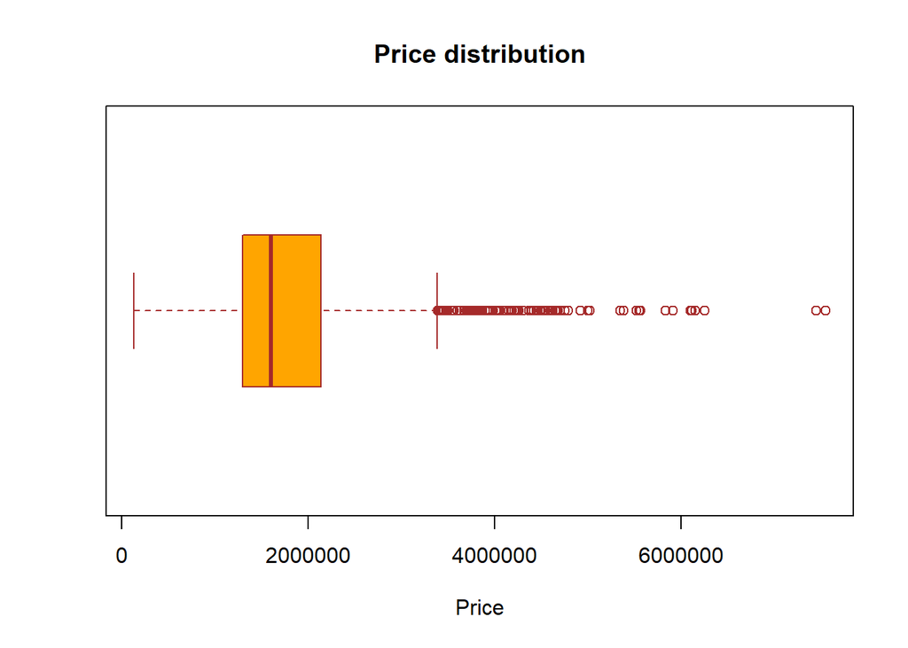

```r
boxplot(test_data$Price, main = "Price distribution", xlab = "Price", col = "orange", border = "brown", horizontal = TRUE)
```

```r
quartiles <- quantile(test_data$Price)
quartiles
```

```
##      0%     25%     50%     75%    100%
##  127890 1299000 1602250 2135000 7550000
```

```r
minPrice <- quartiles[1]
maxPrice <- quartiles[5]
Range <- maxPrice - minPrice

quartile1 <- quartiles[2]
names(quartile1) <- NULL
quartile1
```

```
## [1] 1299000
```

```r
quartile3 <- quartiles[4]
names(quartile3) <- NULL
quartile3
```

```
## [1] 2135000
```

```r
IQR <- quartile3 - quartile1
```

The price distribution of the properties has a wide range from the lowest price being R127890.00 to the largest being R7550000.00, i.e. the Range is R7422110.00. However, most of the properties prices range between R1299000.00 and R2135000.00, with the Interquartile Range being R836000.00.

## Question 3

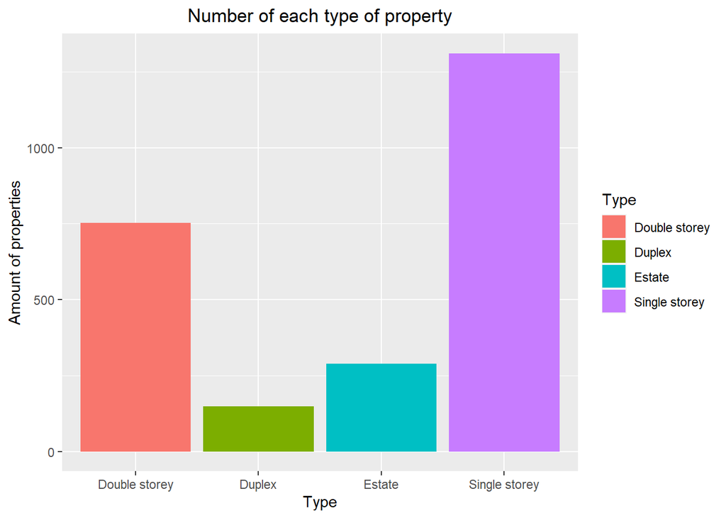

```r
ggplot(data = test_data, aes(x = Type, fill = Type)) + geom_bar() + labs(title = "Number of each type of property", x = "Type", y = "Amount of properties") + theme(plot.title = element_text(hjust = 0.5))
```

## Question 4

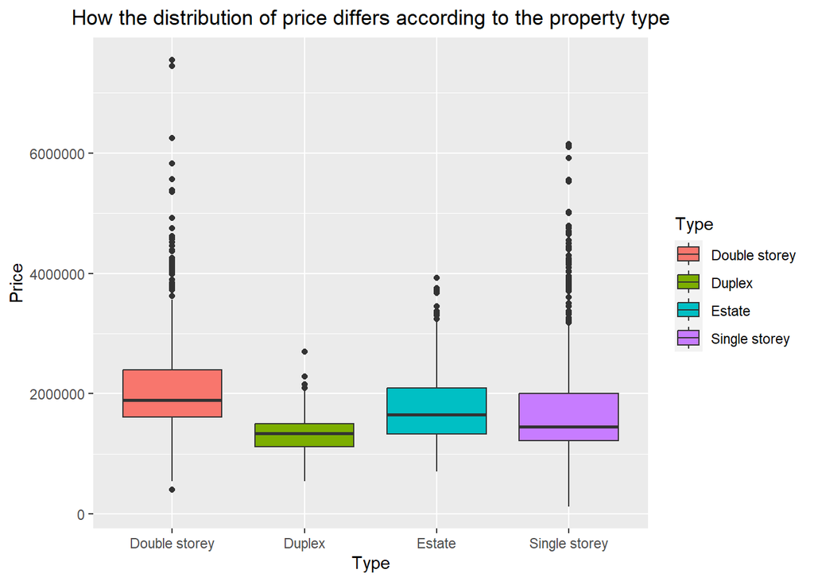

```r
ggplot(data = test_data, aes(x = Type, y = Price, fill = Type)) + geom_boxplot() + labs(title = "How the distribution of price differs according to the property type") + theme(plot.title = element_text(hjust = 0.5))
```

## Question 5

```r
numPropertiesAndAvgPrice <- test_data %>% group_by(Area) %>% summarize(count = n(), mean(Price))
colnames(numPropertiesAndAvgPrice) <- c("Area", "Number of properties", "Average price of properties")
as.data.frame(numPropertiesAndAvgPrice)
```

```
##           Area Number of properties Average price of properties
## 1 Agricultural                    2                    473000.0
## 2   Commercial                   22                    825529.5
## 3   Industrial                    1                   1030000.0
## 4  Residential                 2475                   1824618.4
```

Based on the information in the table above we can deduce that, generally speaking, the agricultural properties have the lowest selling price, residential properties have the highest selling price and the commercial and industrial properties’ selling prices fall in between with commercial following agricultural and industrial following commercial.

## Question 6

```r
missing_values <- sum(is.na(test_data$Street_front))
cordata <- test_data %>% drop_na(Street_front)
cor_Street_front_and_Size <- round(cor(cordata$Street_front, cordata$Size), digits = 3)
```

6.1) There are **421** observations that have missing values for the *Street_front* variable.

6.3) Correlation coefficient = **0.484**, i.e., *Street_front* and *Size* have a *moderate positive linear relationship*.

6.4:

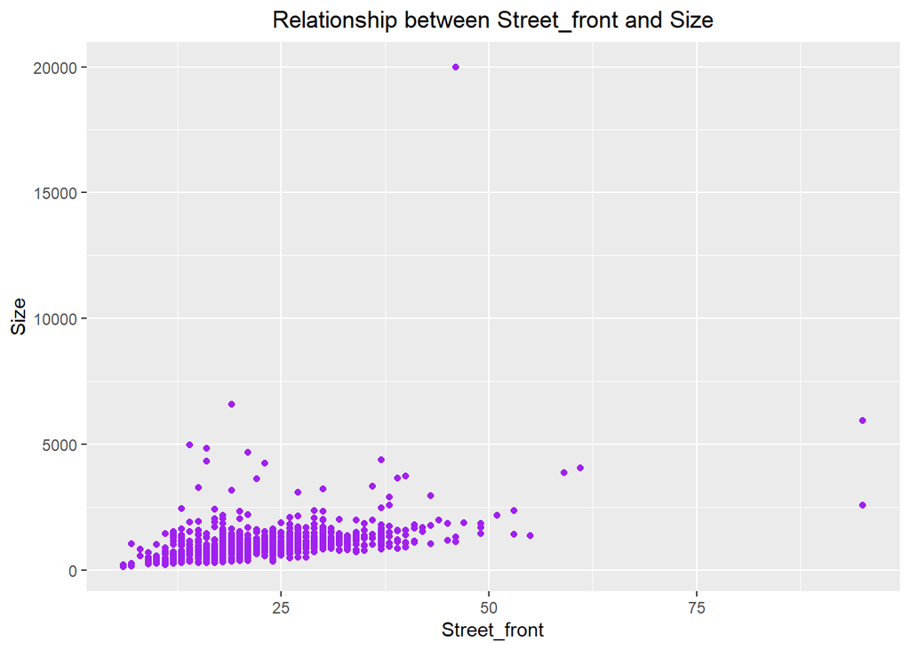

```r
ggplot(data = cordata, mapping = aes(x = Street_front, y = Size)) + geom_point(color="purple") + labs(title = "Relationship between Street_front and Size", x = "Street_front", y = "Size") + theme(plot.title = element_text(hjust = 0.5))
```

Based on the plot above, it does appear that there are outliers, i.e. extremely high or extremely low data points relative to the nearest data point and the rest of the neighboring co-existing values.

Futhermore, based on the computations below for identifying outliers using the IQR method, we can confirm that there are indeed outliers in the data graph:

```r
sf_quartile1 <- quantile(cordata$Street_front, 0.25)

sf_quartile3 <- quantile(cordata$Street_front, 0.75)

IQR_1 <- sf_quartile3 - sf_quartile1

Street_front_outliers <- cordata[(cordata$Street_front < sf_quartile1 - (1.5 * IQR_1)) | (cordata$Street_front > sf_quartile3 + (1.5 * IQR_1)), ]
Street_front_outliers$Street_front
```

```
##   [1] 43 41 51 49 46 59 38 43 39  8  8  6  6  6  6  6  6  6  6  6  7  6  7  7  6
##  [26]  6  6  6  6  6  6  6  6  6  6  6  7  7  7  7  7  7  7  7  7  7  7  7  7  7
##  [51]  7  7 39 34 34 35 34 34 34 34 34 37 34 39 36 37 37 40 34 34 34 36 40 41 39
##  [76] 45 37 55 49 36 53 41 35 34 34 37  7  7  7  7  7  7  7  7  7  7  7  7  7 35
## [101]  7 34 40 35 37 39 42 37 53 38 37 36 36 34 95 34 37 37 44 34 37 37 42 38 38
## [126] 35 37 35 37 37 47 34 36 37 37 41 37 39 40 95  7  7  7 40 34 34  7  7  7  7
## [151]  7  7 37 43 39 46 35 45 34 40 38 38 61 46  6  6  6  6  6  6  6  6  6  6  6
## [176]  6  6  6  6  6  6  6  6  6 38 49
```

```r
sz_quartile1 <- quantile(cordata$Size, 0.25)
sz_quartile3 <- quantile(cordata$Size, 0.75)
IQR_2 <- sz_quartile3 - sz_quartile1
Size_outliers <- cordata[(cordata$Size < sz_quartile1 - (1.5 * IQR_2)) | (cordata$Size > sz_quartile3 + (1.5 * IQR_2)), ]
Size_outliers$Size
```

```
##  [1]  2952  2032  1800  2161  1687  1619  4971  4829  3865  3219  1696  1778
## [13]  1909  1724  1595  2165  1898  1718  2037  3322  1620  2001  4328  1941
## [25]  1812  1652  4670  1613  2361  1793  1979  2056  1626  1977  2569  1708
## [37]  1642  2132  1987  3077  1985  1675  1665  2331  1883  1654  1728  3633
## [49]  4236  1816  1853  1839  2023  1624  2453  1864  6574  1600  1649  4367
## [61]  3650  3725  5935  2023  2083  2422  1626  1626  1825  1676  1672  2191
## [73] 19997  2432  1854  1697  3264  2903  2021  4041  2349  2323  1599  3157
## [85]  2573  1858
```

Handling outliers:

- Removing outliers
  - By identifying outliers as seen above using the IQR method, you can directly filter out outliers.
- Winsorizing
  - This involves setting the outliers to a specified percentile of the data. For example, you can set the outliers to the 5th and 95th percentiles.
- Imputation
  - You can replace the outlier values with statistical measures such as mean, median, or mode.

## Question 7

```r
test_data$Water
```

[output not shown]

[output cut: 53 more lines]

```r
summary(test_data$Water)
```

```
##    Min. 1st Qu.  Median    Mean 3rd Qu.    Max.
##       1       1       1       1       1       1
```

```r
sum = 0
for (i in test_data$Water) {
  if (i == 0){
    sum = sum + 1
  }
}
sum
```

```
## [1] 0
```

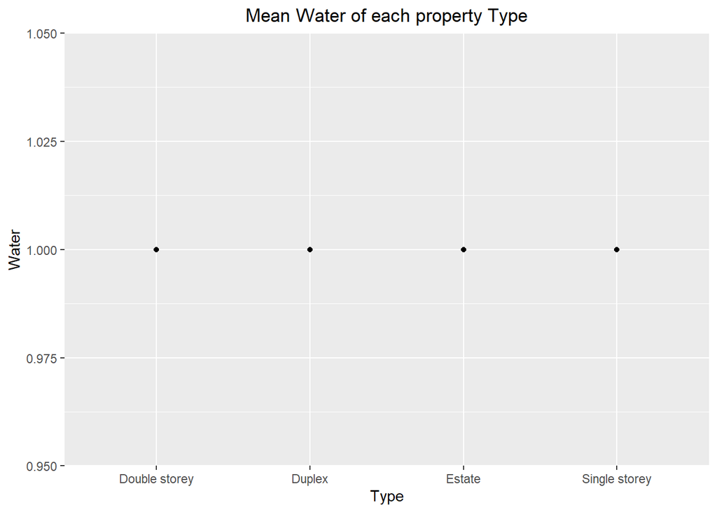

```r
ggplot(data = test_data, aes(x = Type, y = Water)) + geom_point() + labs(title = "Mean Water of each property Type") + theme(plot.title = element_text(hjust = 0.5))
```

The following explains the exploration of the Water variable above (in order) and the conclusion:

1. Displaying what the Water value is for each observation in the data set.
   - Discovering that every observation has the value **1**.
2. Viewing the summary statistics of the Water variable in the data set.
   - All the statistics produce a **1**.
3. Computing the total number of observations with the value of **0** for the Water variable (meaning the observation/property does not have a municipal water connection)
   - Outputting a total of **0**.
4. Plotting the mean Water of each property Type
   - Each property Type has a mean of **1** for the Water variable.

From this exploration of the Water variable, we can conclude that every single property in the data set has a municipal water connection therefore indicating that there is no variation in this variable so it will not be able to estimate or determine property prices.

## Question 8

8.1:

```r
newdata <- mutate(test_data, transport_proximity = case_when(BusyStreet == 1 | NearRail == 1 ~ 1, BusyStreet == 0 & NearRail == 0 ~ 0), not_renovated = case_when(Year_Built==Year_Renov ~ TRUE, Year_Renov>Year_Built ~ FALSE))

#select(newdata, transport_proximity, not_renovated)
transport_proximity_1count <- sum(newdata$transport_proximity)
renovated_count <- 2500 - sum(newdata$not_renovated)
```

8.2) There are **299** properties that are on or near a busy street or near a railway line.

8.3) There are **1168** properties that have been renovated.

8.4:

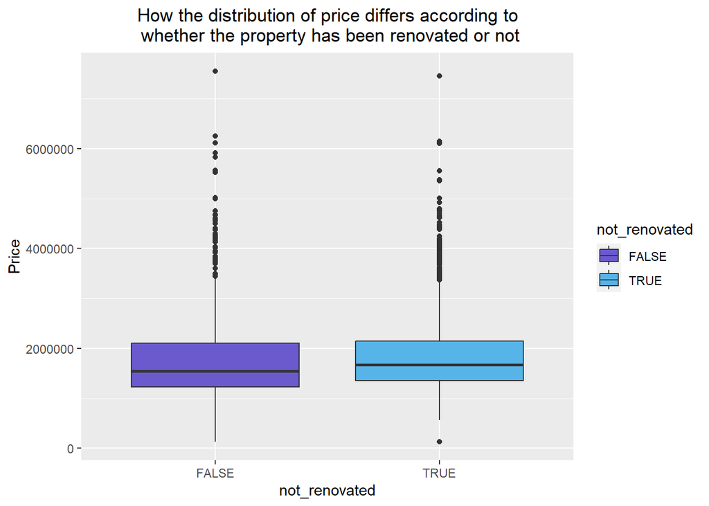

```r
x <- ggplot(data = newdata, aes(x = not_renovated, y = Price, fill = not_renovated)) + geom_boxplot() + labs(title = "How the distribution of price differs according to\n whether the property has been renovated or not") + theme(plot.title = element_text(hjust = 0.5)) + scale_fill_manual(values=c("#6A5ACD", "#56B4E9"))
x
```

```r
#str(ggplot_build(x)$data)
df <- ggplot_build(x)$data
mean_prices <- data.frame(df[[1]]$middle)
mean_price_renovated <- mean_prices[1,]
mean_price_not_renovated<- mean_prices[2,]
mean_price_diff <- mean_price_not_renovated - mean_price_renovated
```

## Question 9

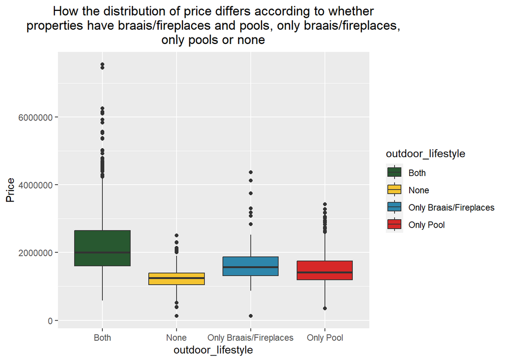

```r
test_data_with_outdoor_lifestyle <- mutate(test_data, outdoor_lifestyle = case_when(Braais_Fireplaces > 0 & Pool == "Yes" ~ "Both", Braais_Fireplaces == 0 & Pool == "No" ~ "None", Braais_Fireplaces > 0 & Pool == "No" ~ "Only Braais/Fireplaces", Braais_Fireplaces == 0 & Pool == "Yes" ~ "Only Pool"))

plot_outdoor_lifestyle <- ggplot(data = test_data_with_outdoor_lifestyle, aes(x = outdoor_lifestyle, y = Price, fill = outdoor_lifestyle)) + geom_boxplot() + labs(title = "How the distribution of price differs according to whether\nproperties have braais/fireplaces and pools, only braais/fireplaces,\nonly pools or none") + theme(plot.title = element_text(hjust = 0.5)) + scale_fill_manual(values=c("#285830", "#F4C431", "#2E86AB", "#D62828"))
plot_outdoor_lifestyle
```

```r
df1 <- ggplot_build(plot_outdoor_lifestyle)$data
min <- data.frame(df1[[1]]$ymin)

q1 <- data.frame(df1[[1]]$lower)

mean_prices <- data.frame(df1[[1]]$middle)

q3 <- data.frame(df1[[1]]$upper)

max <- data.frame(df1[[1]]$ymax)
```

**Table representing the statistics of the boxplot above (quantile for each attribute of the *outdoor_lifestyle* variable):**

```r
outdoor_lifestyle_df <- cbind(min,q1,mean_prices,q3,max)
rownames(outdoor_lifestyle_df) <- c("Both", "None", "Only braais/fireplaces", "Only pool")
colnames(outdoor_lifestyle_df) <- c("Min", "Quartile 1", "Mean", "Quartile 3", "Max")
outdoor_lifestyle_df
```

```
##                           Min Quartile 1    Mean Quartile 3     Max
## Both                   585000    1602000 2000000    2649660 4212500
## None                   550000    1050000 1252500    1391250 1900000
## Only braais/fireplaces 870000    1310000 1570000    1870000 2520000
## Only pool              400000    1192480 1415000    1747225 2550000
```

## Question 10

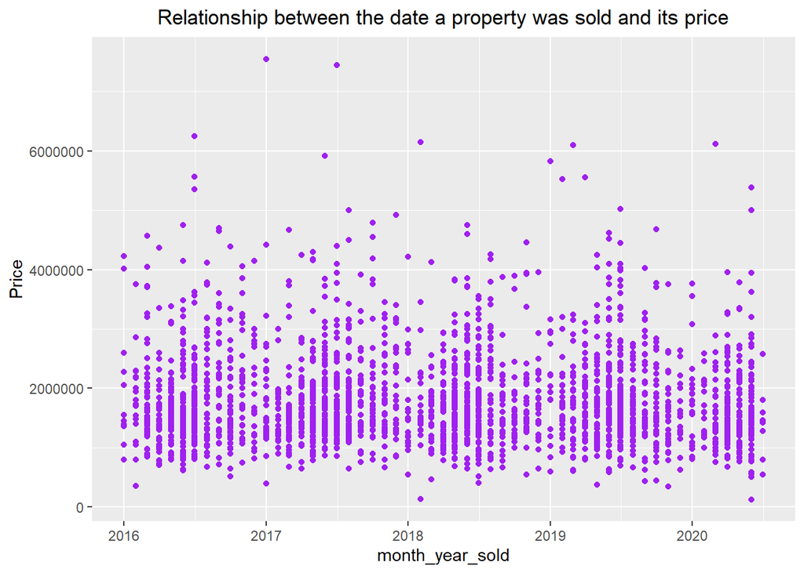

```r
sold_data <- mutate(test_data, month_year_sold = my(paste(Month_sold, Year_sold, sep="-")))
#select(sold_data, Month_sold, Year_sold, month_year_sold)
ggplot(data = sold_data, mapping = aes(x = month_year_sold, y = Price)) + geom_point(color="purple") + labs(title = "Relationship between the date a property was sold and its price", x = "month_year_sold", y = "Price") + theme(plot.title = element_text(hjust = 0.5))
```

- Majority of the prices range between 600000 and 3700000.
- Sales start picking up in about March and increase to the most sales at around June and July and then sales start dipping a bit until January/February, that cycle repeats.
- Generally, more of the more expensive properties get sold around the middle of the year, each year.

## Question 11

11.1)

- Based on the results from question 9, we can determine that the *Braais_Fireplaces* variable will be significant for predicting house prices.
- Since transport is a large component of most peoples daily lives, and since many people own a car/motorbike/scooter, and those people will ideally want their vehicle safe from weather damage and/or theft, I presume *Garages* would be a significant predictor for house prices.
- Based on the results from question 4 of how the distribution of price differs according to the property type, and from my understanding that based on the type of property you have (apartment, single storey house, double storey house, house in estate, duplex etc.) the price will differ drastically since, for example, a house in a secured, well-maintained and beautiful estate would typically cost a lot more than a standard apartment in a block of flats. Therefore I presume *Type* will be a significant predictor on house prices.
- It seems intuitive to presume that the size of your property/land/house is directly proportional to the price of the property. Even if you just think in terms of land, the bigger area of land you own, the more value it should have. Therefore I estimate that *Size* will be a significant predictor on house prices.

11.2)

**Attribute evaluation table of the test_data data set using the information gain method (decreasing order, from highest information gain to lowest and read from left to right):**

```r
sort(round(attrEval(formula = Price_cat ~ Month_sold+Year_sold+Sale_type+Type+Area+Size+Street_front+Plot_shape+Incline+SlopeType+Condition+Year_Built+Year_Renov+Tarred_road+Culdesac+Corner+Roof_Type+Bathrooms+Bedrooms+KitchenCondition+Braais_Fireplaces+Garages+Driveway+Pool+BusyStreet+NearRail+NearGreen, data = test_data, estimator = "InfGain"), digits = 10), decreasing = TRUE)
```

```
##        Year_Built           Garages         Bathrooms        Year_Renov
##      0.3209221808      0.2561776648      0.2428109772      0.2161663043
## Braais_Fireplaces         Condition      Street_front              Size
##      0.1897196756      0.1687070533      0.1174116211      0.1099026848
##  KitchenCondition              Type        Plot_shape          Driveway
##      0.0979633680      0.0847675493      0.0809143515      0.0786057042
##              Pool          Bedrooms        BusyStreet          Culdesac
##      0.0573760685      0.0307373450      0.0263702287      0.0181011929
##              Area           Incline         Sale_type         NearGreen
##      0.0155016549      0.0136458063      0.0086749834      0.0086003482
##         SlopeType        Month_sold       Tarred_road          NearRail
##      0.0039176627      0.0032079735      0.0025758352      0.0015938696
##         Year_sold         Roof_Type            Corner
##      0.0015396710      0.0003260683      0.0002246326
```

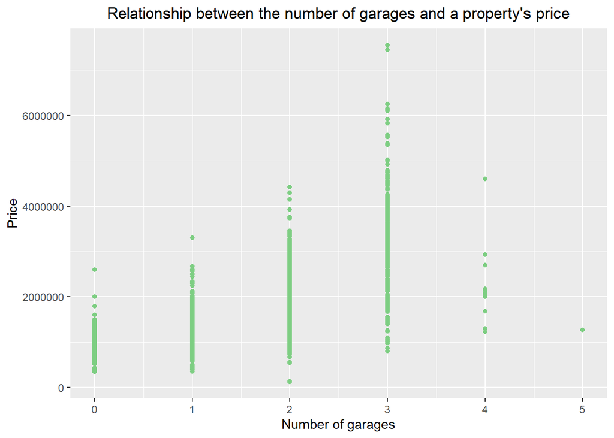

```r
cordata2 <- test_data %>% drop_na(Garages)
ggplot(data = cordata2, mapping = aes(x = Garages, y = Price)) + geom_point(color="#7DCE82") + labs(title = "Relationship between the number of garages and a property's price", x = "Number of garages", y = "Price") + theme(plot.title = element_text(hjust = 0.5))
```

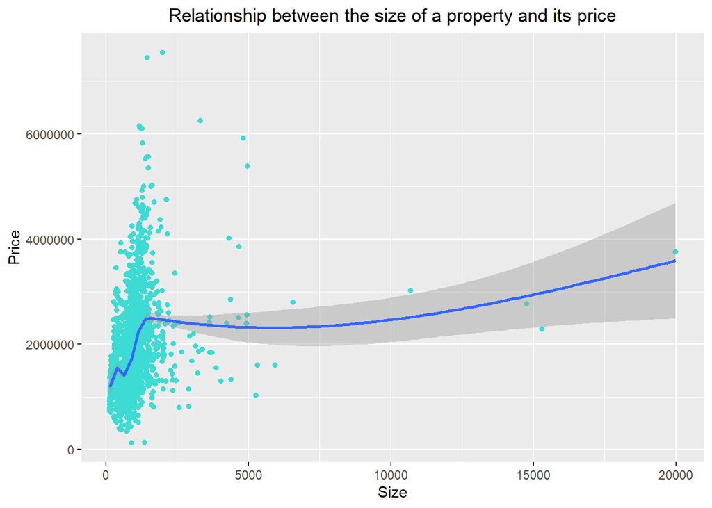

```r
ggplot(data = test_data, mapping = aes(x = Size, y = Price)) + geom_point(color="#3CDBD3") + labs(title = "Relationship between the size of a property and its price", x = "Size", y = "Price") + theme(plot.title = element_text(hjust = 0.5)) + geom_smooth()
```

**Table representing the correlation coefficient between Garages and Price, Size and Price, as well as Braais_Fireplaces and Price:**

```r
cor_garages_price <- cor(cordata2$Garages, cordata2$Price)
cor_size_price <- cor(test_data$Size, test_data$Price)
cor_braais_price <- cor(test_data$Braais_Fireplaces, test_data$Price)

cor_df <- cbind(cor_garages_price, cor_size_price, cor_braais_price)
rownames(cor_df) <- c("Price")
colnames(cor_df) <- c("Garages", "Size", "Braais_Fireplaces")
cor_df
```

```
##         Garages      Size Braais_Fireplaces
## Price 0.6458331 0.2626248         0.4699402
```

I was quite spot on with my supposition for *Garages* and *Braais_Fireplaces* since those variables are in the top 5 variables (out of 27) with the highest information gain value in the attribute evaluation implying that they are significant variables for predicting house prices. Furthermore, the plot from question 9 also indicates that having braais/fireplaces in the property significantly increases the price, on average, compared to properties with no braais/fireplaces, similarly, the plot above showing the relationship between number of garages and the price shows that having more garages generally increases the property’s price by a significant margin. Furthermore, in the table above showing correlation coefficients between the variables, *Garages* does indeed have a pretty strong positive linear relationship with *Price* and *Braais_Fireplaces* having a moderate positive linear relationship. Whereas with *Size* and *Type*, I slightly over-valued their significance to predict house prices in my supposition. However, they still fall in the top 10 variables (out of 27) with the highest information gain value in the attribute evaluation (with *Size* being 8th and *Type* being 10th).

## Question 12

12.1 and 12.2)

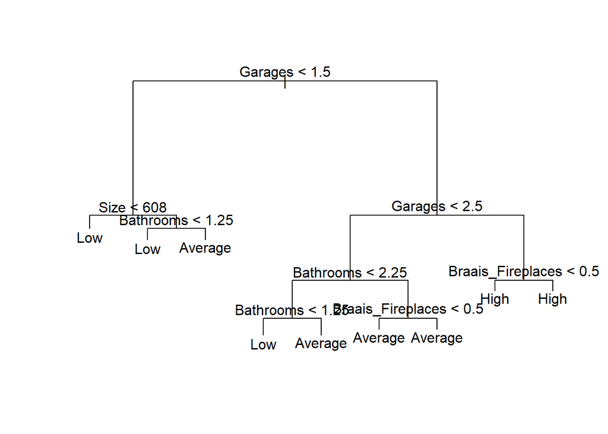

```r
tree.properties <- tree(Price_cat ~ Area+Type+Size+Corner+Bathrooms+Bedrooms+KitchenCondition+Braais_Fireplaces+Garages+Driveway+Pool, data = test_data)
plot(tree.properties)
text(tree.properties)
```

12.3)

```r
summary(tree.properties)
```

```
##
## Classification tree:
## tree(formula = Price_cat ~ Area + Type + Size + Corner + Bathrooms +
##     Bedrooms + KitchenCondition + Braais_Fireplaces + Garages +
##     Driveway + Pool, data = test_data)
## Variables actually used in tree construction:
## [1] "Garages"           "Size"              "Bathrooms"
## [4] "Braais_Fireplaces"
## Number of terminal nodes:  9
## Residual mean deviance:  1.311 = 3265 / 2490
## Misclassification error rate: 0.3057 = 764 / 2499
```

```r
ratio <- summary(tree.properties)[[7]]
misclassification.error.rate <- round(ratio[1] / ratio[2], digits = 4)
misclassification.error.rate
```

```
## [1] 0.3057
```

From the summary of the decision tree above we can see that the misclassification error rate on the training data is **0.3057**.

12.4)

```r
new_obs <- data.frame(Area = "Residential", Type = "Single storey", Size = 1300, Corner = 0, Bathrooms = 4, Bedrooms = 5, KitchenCondition = 1, Braais_Fireplaces = 3, Garages = 2, Driveway = "Paved", Pool = "Yes", stringsAsFactors = TRUE)

prediction <- predict(tree.properties, new_obs, type = 'class')
prediction
```

```
## [1] Average
## Levels: Average High Low
```

The prediction of the price category of the given property is **Average**.